# ANIMAL RECOGNITION AND AUTOMATED WILDLIFE MONITORING WITH DEEP LEARNING

Dataset: `https://www.kaggle.com/datasets/antoreepjana/animals-detection-images-dataset`

First, we import all the libraries required. The main libraries come from `tensorflow` and `keras`.

```python
from tensorflow import keras
import tensorflow as tf
import numpy as np
import matplotlib.pyplot as plt

from keras.preprocessing.image import ImageDataGenerator
from keras.callbacks import EarlyStopping

from keras.models import Model, Sequential
from keras.layers import Dense, Flatten, Dropout, Conv2D, MaxPooling2D
from keras import regularizers

from keras.applications.vgg16 import VGG16
from keras.applications.resnet import ResNet50
from keras.applications.inception_resnet_v2 import InceptionResNetV2
from keras.optimizers import Adam

from keras.applications.vgg16 import preprocess_input
import os
import pandas as pd
```

Setting the paths to the dataset.

The dataset structure looks like:

```
├── data
│   ├── test
│   │   ├── Bear
│   │   ├── Bull
│   │   ├── Butterfly
│   │   ├── ...
│   │
│   ├── train
│   │   ├── Bear
│   │   ├── Bull
│   │   ├── Butterfly
│   │   ├── ...
```

```python
# Path to test directory
test_data_dir = "/wildlife-classification/data/test"
# Path to train directory
train_data_dir = "/wildlife-classification/data/train"
```

First we are getting all the class names using the `os.listdir()` method. After that we iterate through the class names to firstly get the train and test image counts. We then get the total image counts and this is used to calculate the test and train percentages for each class. We then add it to a data frame and plot it to show the distribution of test and train images for all the classes.

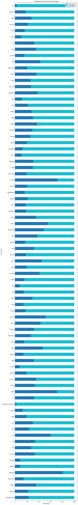

```python
# Get the list of class names
class_names = os.listdir(train_data_dir)

# Create a Pandas DataFrame
df = pd.DataFrame(columns=["class_name", "test_percent", "train_percent"])

# Iterate over the class names
for name in class_names:

    # Get the number of test images
    test_image_count = len(os.listdir(os.path.join(test_data_dir, name)))

    # Get the number of train images
    train_image_count = len(os.listdir(os.path.join(train_data_dir, name)))

    # Get the total number of images
    total_image_count = test_image_count + train_image_count

    # Calculate the test percentage
    test_percent = round((test_image_count / total_image_count) * 100, 2)

    # Calculate the train percentage
    train_percent = round((train_image_count / total_image_count) * 100, 2)

    # Add the data to the DataFrame
    df = pd.concat([df, pd.DataFrame({"class_name": name, "test_percent": test_percent, "train_percent": train_percent}, index=[name])])


# Plot the data
df.plot(
    kind="barh",
    stacked=True,
    figsize=(
        10,
        80,
    ),
    colormap="tab10",
    title="Distribution of Test and Train Images",
    xlabel="Percentage",
    ylabel="Class Name",
    legend=True,
)
```

```python
ANIMAL_TYPES = len(class_names)
IMAGE_SIZE = [224, 224]
```

We are declaring the architecture and hyper-parameters for the first model here.

We have 3 layers which we are freezing. Firstly we get the base model with pre-trained weights from the `imagenet` set and set the input shape as `224x224`. The subsequent lines define additional layers and connections to the base model. The flatten layer converts the output of the base model into a 1D feature vector. The dropout layer randomly sets a fraction (50%) of the input units to 0 at each update during training, which helps prevent overfitting. The output layer is a dense layer with softmax activation, producing probabilities for each class.

```python
with tf.device('/gpu:0'):
    INCEPTION_FREEZE_LAYERS = 3

    inception_resnet_base_model = InceptionResNetV2(include_top=False,
                            weights='imagenet',
                            input_tensor=None,
                            input_shape=(IMAGE_SIZE[0],IMAGE_SIZE[1],3))

    InceptionBaseOutput = inception_resnet_base_model.output
    InceptionFlattenLayer = Flatten()(InceptionBaseOutput)
    InceptionDropoutLayer = Dropout(0.5)(InceptionFlattenLayer)
    InceptionOutputLayer = Dense(ANIMAL_TYPES, activation='softmax', name='softmax')(InceptionDropoutLayer)

    inception_resnet_model = Model(inputs=inception_resnet_base_model.input, outputs=InceptionOutputLayer)

    for layer in inception_resnet_model.layers[:INCEPTION_FREEZE_LAYERS]:
        layer.trainable = False
    for layer in inception_resnet_model.layers[INCEPTION_FREEZE_LAYERS:]:
        layer.trainable = True

    inception_resnet_model.compile(optimizer=Adam(learning_rate=1e-5),
                      loss='categorical_crossentropy', metrics=['accuracy'])
```

```
Downloading data from https://storage.googleapis.com/tensorflow/keras-applications/inception_resnet_v2/inception_resnet_v2_weights_tf_dim_ordering_tf_kernels_notop.h5
```

```python
inception_resnet_base_model.summary()
```

```
Model: "inception_resnet_v2"
__________________________________________________________________________________________________
 Layer (type)                   Output Shape         Param #     Connected to
==================================================================================================
 input_1 (InputLayer)           [(None, 224, 224, 3  0           []
                                )]

 conv2d (Conv2D)                (None, 111, 111, 32  864         ['input_1[0][0]']
                                )

 batch_normalization (BatchNorm  (None, 111, 111, 32  96         ['conv2d[0][0]']
 alization)                     )

 activation (Activation)        (None, 111, 111, 32  0           ['batch_normalization[0][0]']
                                )

 conv2d_1 (Conv2D)              (None, 109, 109, 32  9216        ['activation[0][0]']
                                )

 batch_normalization_1 (BatchNo  (None, 109, 109, 32  96         ['conv2d_1[0][0]']
 rmalization)                   )

 activation_1 (Activation)      (None, 109, 109, 32  0           ['batch_normalization_1[0][0]']
                                )

 conv2d_2 (Conv2D)              (None, 109, 109, 64  18432       ['activation_1[0][0]']
                                )

 batch_normalization_2 (BatchNo  (None, 109, 109, 64  192        ['conv2d_2[0][0]']
 rmalization)                   )

 activation_2 (Activation)      (None, 109, 109, 64  0           ['batch_normalization_2[0][0]']
                                )

 max_pooling2d (MaxPooling2D)   (None, 54, 54, 64)   0           ['activation_2[0][0]']

 conv2d_3 (Conv2D)              (None, 54, 54, 80)   5120        ['max_pooling2d[0][0]']

 batch_normalization_3 (BatchNo  (None, 54, 54, 80)  240         ['conv2d_3[0][0]']
 rmalization)
```

[output cut: 1864 more lines]

```
 block8_10 (Lambda)             (None, 5, 5, 2080)   0           ['block8_9_ac[0][0]',
                                                                  'block8_10_conv[0][0]']

 conv_7b (Conv2D)               (None, 5, 5, 1536)   3194880     ['block8_10[0][0]']

 conv_7b_bn (BatchNormalization  (None, 5, 5, 1536)  4608        ['conv_7b[0][0]']
 )

 conv_7b_ac (Activation)        (None, 5, 5, 1536)   0           ['conv_7b_bn[0][0]']

==================================================================================================
Total params: 54,336,736
Trainable params: 54,275,328
Non-trainable params: 61,408
__________________________________________________________________________________________________
```

A similar approach has been taken for the ResNet50 model as well. We are using pre-trained weights here as well and setting the shape as `224x224`. Here however, we only freeze 2 layers instead of 3 mentioned in the previous architecture. This brought more optimistic results for this model. The hyper parameters for `learning_rate` and `FREEZE_LAYERS` have been set here.

```python
with tf.device('/gpu:0'):
    FREEZE_LAYERS = 2

    resnet_base_model = ResNet50(include_top=False, weights='imagenet', input_tensor=None,
                   input_shape=(IMAGE_SIZE[0],IMAGE_SIZE[1],3))

    BaseOutput = resnet_base_model.output
    FlattenNetLayer = Flatten()(BaseOutput)
    DropoutNetLayer = Dropout(0.5)(FlattenNetLayer)
    OutputNetLayer = Dense(ANIMAL_TYPES, activation='softmax', name='softmax')(DropoutNetLayer)

    resnet_model = Model(inputs=resnet_base_model.input, outputs=OutputNetLayer)

    for layer in resnet_model.layers[:FREEZE_LAYERS]:
        layer.trainable = False

    for layer in resnet_model.layers[FREEZE_LAYERS:]:
        layer.trainable = True

    resnet_model.compile(optimizer=Adam(learning_rate=1e-5),
                      loss='categorical_crossentropy', metrics=['accuracy'])
```

```
Downloading data from https://storage.googleapis.com/tensorflow/keras-applications/resnet/resnet50_weights_tf_dim_ordering_tf_kernels_notop.h5
```

Using the `.summary()` method, we are able to visualize the ResNet50 model we have designed.

```python
resnet_model.summary()
```

```
Model: "model"
__________________________________________________________________________________________________
 Layer (type)                   Output Shape         Param #     Connected to
==================================================================================================
 input_1 (InputLayer)           [(None, 224, 224, 3  0           []
                                )]

 conv1_pad (ZeroPadding2D)      (None, 230, 230, 3)  0           ['input_1[0][0]']

 conv1_conv (Conv2D)            (None, 112, 112, 64  9472        ['conv1_pad[0][0]']
                                )

 conv1_bn (BatchNormalization)  (None, 112, 112, 64  256         ['conv1_conv[0][0]']
                                )

 conv1_relu (Activation)        (None, 112, 112, 64  0           ['conv1_bn[0][0]']
                                )

 pool1_pad (ZeroPadding2D)      (None, 114, 114, 64  0           ['conv1_relu[0][0]']
                                )

 pool1_pool (MaxPooling2D)      (None, 56, 56, 64)   0           ['pool1_pad[0][0]']

 conv2_block1_1_conv (Conv2D)   (None, 56, 56, 64)   4160        ['pool1_pool[0][0]']

 conv2_block1_1_bn (BatchNormal  (None, 56, 56, 64)  256         ['conv2_block1_1_conv[0][0]']
 ization)

 conv2_block1_1_relu (Activatio  (None, 56, 56, 64)  0           ['conv2_block1_1_bn[0][0]']
 n)

 conv2_block1_2_conv (Conv2D)   (None, 56, 56, 64)   36928       ['conv2_block1_1_relu[0][0]']

 conv2_block1_2_bn (BatchNormal  (None, 56, 56, 64)  256         ['conv2_block1_2_conv[0][0]']
 ization)

 conv2_block1_2_relu (Activatio  (None, 56, 56, 64)  0           ['conv2_block1_2_bn[0][0]']
 n)

 conv2_block1_0_conv (Conv2D)   (None, 56, 56, 256)  16640       ['pool1_pool[0][0]']
```

[output cut: 428 more lines]

```
                                                                  'conv5_block3_3_bn[0][0]']

 conv5_block3_out (Activation)  (None, 7, 7, 2048)   0           ['conv5_block3_add[0][0]']

 flatten (Flatten)              (None, 100352)       0           ['conv5_block3_out[0][0]']

 dropout (Dropout)              (None, 100352)       0           ['flatten[0][0]']

 softmax (Dense)                (None, 80)           8028240     ['dropout[0][0]']

==================================================================================================
Total params: 31,615,952
Trainable params: 31,562,832
Non-trainable params: 53,120
__________________________________________________________________________________________________
```

This is where image resizing and data augmentation is taking place. Here, we are setting the `BATCH_SIZE` of 30 after completing multiple iterations and 30 seemed to bring the best results with the least training time. We do multiple image preprocessing functions to improve the accuracy of the model. The `train_data_gen` mentioned here includes all the pre-processing techniques that have been used for this model. The `train_data` is then shuffled to make sure the model does not overfit. That is the reason `shuffle=True` is there on the `train_data` but it's `false` on the `test_data`.

```python
BATCH_SIZE = 30

train_data_gen = ImageDataGenerator(
    preprocessing_function=preprocess_input,
    rotation_range=40,
    width_shift_range=0.2,
    height_shift_range=0.2,
    shear_range=0.2,
    zoom_range=0.2,
    channel_shift_range=10,
    horizontal_flip=True,
    fill_mode='nearest',
)

train_data = train_data_gen.flow_from_directory(
    directory=train_data_dir,
    target_size=IMAGE_SIZE,
    batch_size=BATCH_SIZE,
    class_mode='categorical',
    shuffle=True,
    subset='training',
    interpolation='bicubic',
)

valid_data_gen = ImageDataGenerator(preprocessing_function=preprocess_input)

test_data  = valid_data_gen.flow_from_directory(
    directory=test_data_dir,
    target_size=IMAGE_SIZE,
    batch_size=BATCH_SIZE,
    class_mode='categorical',
    shuffle=False,
    interpolation='bicubic',
)
```

```
Found 22566 images belonging to 80 classes.
Found 6505 images belonging to 80 classes.
```

Early stopping is applied with a patience of 2. That means if the `val_loss` does not decrease in 2 epochs, the fitting will stop since the model is not learning anymore. This is to save both time and power resources.

```python
es = EarlyStopping(monitor='val_loss', patience=2)
```

Using a `GPU` we try to fit the model using 15 epochs. We set the `es` (early_stopping) as a callback and run the model. Here, the early stopping is triggered since the `val_loss` does not seem to improve much after the 10th epoch. The model is however, able to reach a `val_accuracy` of 82.42%

```python
with tf.device('/gpu:0'):
    inception_resnet_history = inception_resnet_model.fit(
        train_data,
        validation_data = test_data,
        epochs = 15,
        steps_per_epoch= len(train_data.filenames)//BATCH_SIZE,
        validation_steps=len(test_data.filenames)//BATCH_SIZE,
        callbacks=[es]
    )
```

We then save the trained model so that it can be used later on to do further validations and testing.

```python
inception_resnet_model.save('inception_resnet_model_1.h5')
```

Here, we are plotting the loss and accuracy graphs to see if the model has overfit or underfit. From the plots we can see that there is no significant overfit or underfit of the model.

```python
inception_model_epochs_range = range(11)

inception_training_acc = inception_resnet_history.history['accuracy']
inception_validation_acc = inception_resnet_history.history['val_accuracy']

inception_training_loss = inception_resnet_history.history['loss']
inception_validation_loss = inception_resnet_history.history['val_loss']

# Create a pd Dataframe for accuracy
inception_acc_df = pd.DataFrame({"Training Accuracy":inception_training_acc, "Validation Accuracy":inception_validation_acc}, index=inception_model_epochs_range)
# Create a pd Dataframe for loss
inception_loss_df = pd.DataFrame({"Training Loss":inception_training_loss, "Validation Loss":inception_validation_loss}, index=inception_model_epochs_range)
```

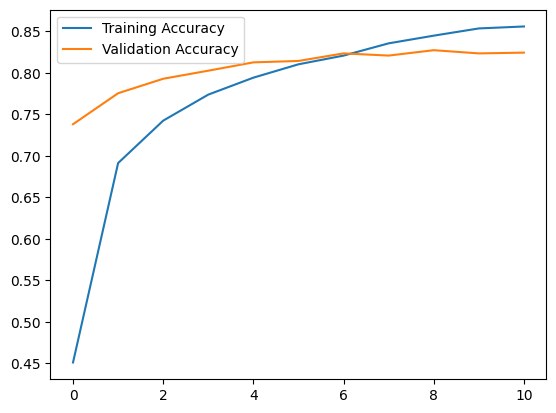

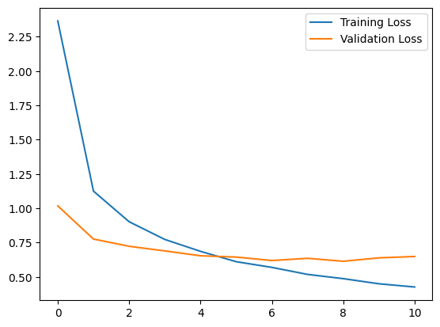

```python
inception_acc_df.plot()
inception_loss_df.plot()
```

```python
with tf.device('/gpu:0'):
    resnet_history = resnet_model.fit(
        train_data,
        validation_data = test_data,
        epochs = 15,
        steps_per_epoch= len(train_data.filenames)//BATCH_SIZE,
        validation_steps=len(test_data.filenames)//BATCH_SIZE,
        callbacks=[es]
    )
```

We save the model using the `.save()` function so that it can later be used for validation and testing.

```python
resnet_model.save('resnet50_model_1.h5')
```

Here, we are plotting the loss and accuracy of the model against the epochs. We can see that as the model was training the validation accuracy increased and the validation loss decreased. This is proof that the model was learning. We also cannot see any significant overfitting or underfitting meaning the model has been appropriately trained.

```python
epochs_range = range(15)

training_acc = resnet_history.history['accuracy']
validation_acc = resnet_history.history['val_accuracy']

training_loss = resnet_history.history['loss']
validation_loss = resnet_history.history['val_loss']

# Create a pd Dataframe for accuracy
acc_df = pd.DataFrame({"Training Accuracy":training_acc, "Validation Accuracy":validation_acc}, index=epochs_range)
# Create a pd Dataframe for loss
loss_df = pd.DataFrame({"Training Loss":training_loss, "Validation Loss":validation_loss}, index=epochs_range)
```

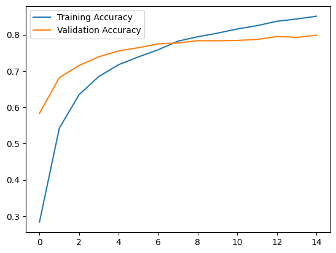

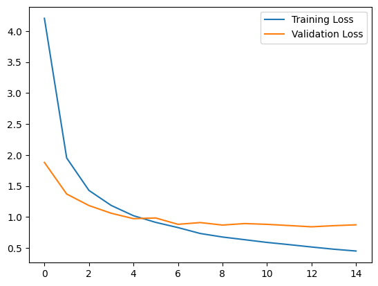

```python
acc_df.plot()
loss_df.plot()
```

We are doing manual validation of the models here. We are taking images which the model has not seen yet in training or testing for validation and seeing how the model is performing.

We first load the models, use the `.predict()` function to get the probabilities and from the `np.argmax()` we take the highest probability and check the name of the class which follows the index of the highest probability. We then show the image along with the class name and the confidence on a subplot.

[figure not shown]

```python
sorted_class_names = sorted(class_names)

# Load the model
resnet_trained_model = keras.models.load_model('resnet50_model_1.h5')
inception_resnet_trained_model = keras.models.load_model('inception_resnet_model_1.h5')

# Load the image
img = keras.preprocessing.image.load_img('/wildlife-classification/fish.jpg', target_size=(224, 224))

# Predict the class
resnet_result = resnet_trained_model.predict(keras.preprocessing.image.img_to_array(img).reshape(1, 224, 224, 3))
inception_resnet_result = inception_resnet_trained_model.predict(keras.preprocessing.image.img_to_array(img).reshape(1, 224, 224, 3))

# Get the predicted class
resnet_predicted_class = np.argmax(resnet_result)
inception_resnet_predicted_class = np.argmax(inception_resnet_result)

# Create subplots
fig, axs = plt.subplots(nrows=1, ncols=2, figsize=(10, 5))

# Plot data on first subplot
axs[0].imshow(img)
axs[0].axis('off')
axs[0].set_title('ResNet50 Predicted Class: ' + sorted_class_names[resnet_predicted_class] + '\nProbability: ' + str(round(resnet_result[0][resnet_predicted_class]*100, 2)) + '%')

# Plot data on second subplot
axs[1].imshow(img)
axs[1].axis('off')
axs[1].set_title('Inception ResNet V2 Predicted Class: ' + sorted_class_names[inception_resnet_predicted_class] + '\nProbability: ' + str(round(inception_resnet_result[0][inception_resnet_predicted_class]*100, 2)) + '%')


# Adjust layout and display the plot
plt.tight_layout()
plt.show()
```